# Interpretability and Explainability in Machine Learning

```r
# Load the concrete dataset
library(readxl)
concrete <- as.data.frame(read_excel("Concrete_Data.xls"))
DescVars <- names(concrete)
names(concrete) <- c(
  "Cement", "Slag", "FlyAsh", "Water", "Superplast",
  "CoarseAggr", "FineAggr", "Age", "Strength"
)
```

**Data processing: Creating training and test sets**  
Create a training sample choosing 700 data at random. The non-chosen data will be the test set.

```r
# Set a seed for reproducibility
set.seed(123456)

# Create indices for the training set
train_indices <- sort(sample(1:nrow(concrete), size = 700, replace = FALSE))

# Split the data into training and test sets
train_set <- concrete[train_indices, ]
test_set <- concrete[-train_indices, ]

# Check the dimensions of the splits
cat("Training set dimensions: ", dim(train_set), "\n")
```

```
## Training set dimensions:  700 9
```

```r
cat("Test set dimensions: ", dim(test_set), "\n")
```

```
## Test set dimensions:  330 9
```

**1. Fit a Random Forest**

1. Compute the *Variable Importance* by the reduction of the **impurity** at the splits defined by each variable.

```r
library(ranger)
model_rf_imp <- ranger(
  Strength ~ .,
  data = train_set,
  importance = "impurity"
)
print(model_rf_imp)
```

```
## Ranger result
##
## Call:
##  ranger(Strength ~ ., data = train_set, importance = "impurity")
##
## Type:                             Regression
## Number of trees:                  500
## Sample size:                      700
## Number of independent variables:  8
## Mtry:                             2
## Target node size:                 5
## Variable importance mode:         impurity
## Splitrule:                        variance
## OOB prediction error (MSE):       36.04991
## R squared (OOB):                  0.8721256
```

2. Compute the *Variable Importance* by out-of-bag random permutations.

```r
model_rf_perm <- ranger(
  Strength ~ .,
  data = train_set,
  importance = "permutation"
)
print(model_rf_perm)
```

```
## Ranger result
##
## Call:
##  ranger(Strength ~ ., data = train_set, importance = "permutation")
##
## Type:                             Regression
## Number of trees:                  500
## Sample size:                      700
## Number of independent variables:  8
## Mtry:                             2
## Target node size:                 5
## Variable importance mode:         permutation
## Splitrule:                        variance
## OOB prediction error (MSE):       34.82129
## R squared (OOB):                  0.8764837
```

3. Do a graphical representation of both *Variable Importance* measures.

```r
library(vip)
library(gridExtra)
```

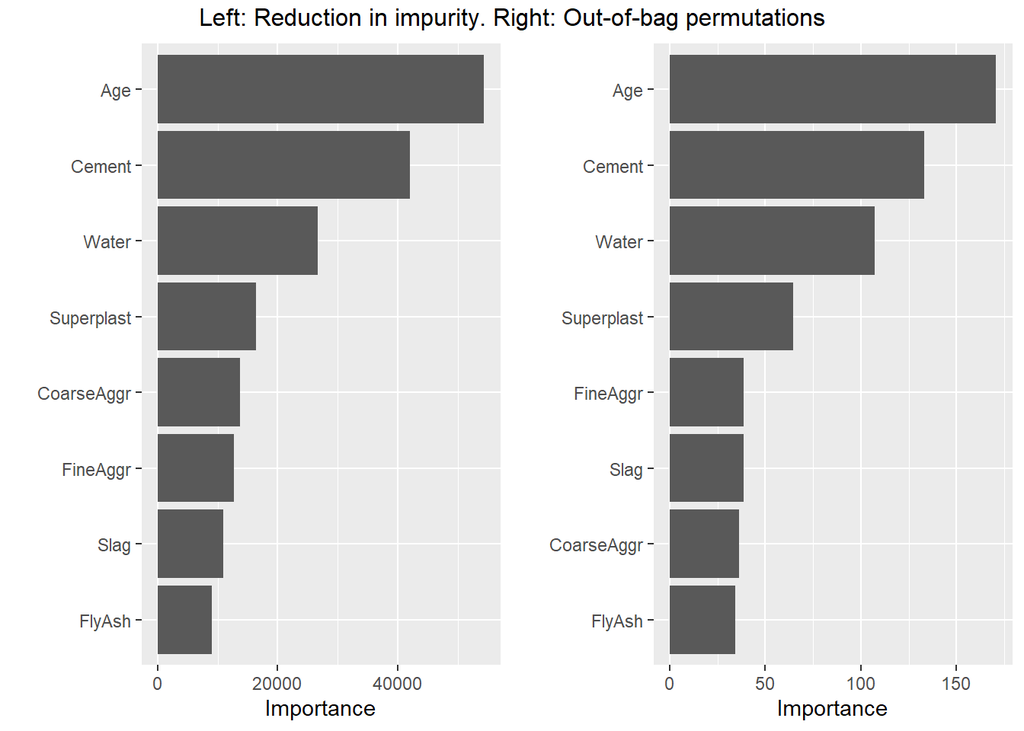

```r
rf_imp_vip <- vip(model_rf_imp, num_features = 8)
rf_perm_vip <- vip(model_rf_perm, num_features = 8)
grid.arrange(rf_imp_vip, rf_perm_vip,
  ncol = 2,
  top = "Left: Reduction in impurity. Right: Out-of-bag permutations"
)
```

4. Compute the *Variable Importance* of each variable by Shapley Values.

```r
library(DALEX)
```

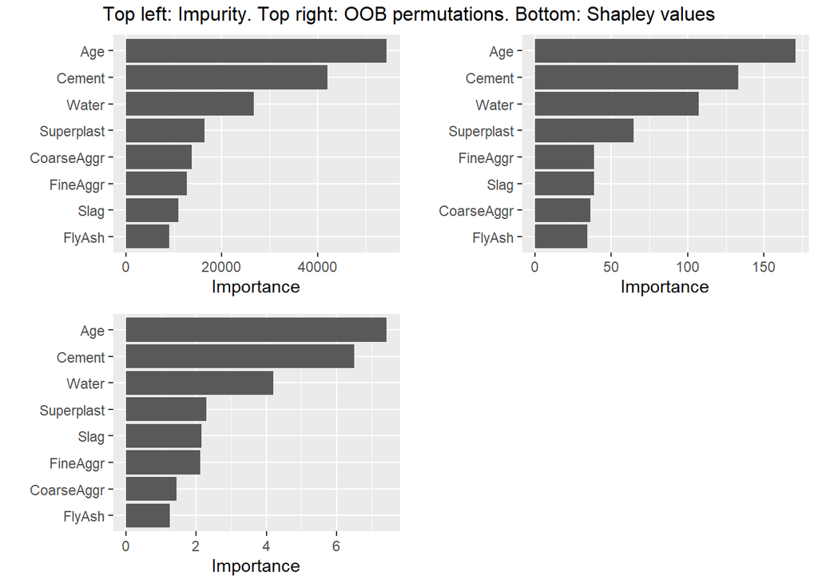

```r
rf_shapley <- vip(
  model_rf_imp,
  method = "shap",
  pred_wrapper = yhat,
  num_features = 8,
  train = train_set,
  newdata = test_set[, -which(names(test_set) == "Strength")]
)

grid.arrange(rf_imp_vip, rf_perm_vip, rf_shapley,
  ncol = 2, nrow = 2,
  top = "Top left: Impurity. Top right: OOB permutations. Bottom: Shapley values"
)
```

**2. Fit a linear model and a gam model**

1. Summarize, numerically and graphically, the fitted models.

```r
# Linear model fit
lm_concrete <- lm(Strength ~ ., data = train_set)

# Numerical summary of the fitted model
(summ_lm_concrete <- summary(lm_concrete))
```

```
##
## Call:
## lm(formula = Strength ~ ., data = train_set)
##
## Residuals:
##     Min      1Q  Median      3Q     Max
## -28.566  -6.385   0.574   6.857  35.263
##
## Coefficients:
##              Estimate Std. Error t value Pr(>|t|)
## (Intercept) -5.521940  33.631106  -0.164 0.869628
## Cement       0.117746   0.010613  11.095  < 2e-16 ***
## Slag         0.093833   0.012710   7.383 4.47e-13 ***
## FlyAsh       0.080704   0.015775   5.116 4.05e-07 ***
## Water       -0.168127   0.050434  -3.334 0.000903 ***
## Superplast   0.289666   0.115940   2.498 0.012706 *
## CoarseAggr   0.008933   0.011938   0.748 0.454546
## FineAggr     0.015489   0.013509   1.147 0.251960
## Age          0.110749   0.006502  17.033  < 2e-16 ***
## ---
## Signif. codes:  0 '***' 0.001 '**' 0.01 '*' 0.05 '.' 0.1 ' ' 1
##
## Residual standard error: 10.59 on 691 degrees of freedom
## Multiple R-squared:  0.6071, Adjusted R-squared:  0.6025
## F-statistic: 133.5 on 8 and 691 DF,  p-value: < 2.2e-16
```

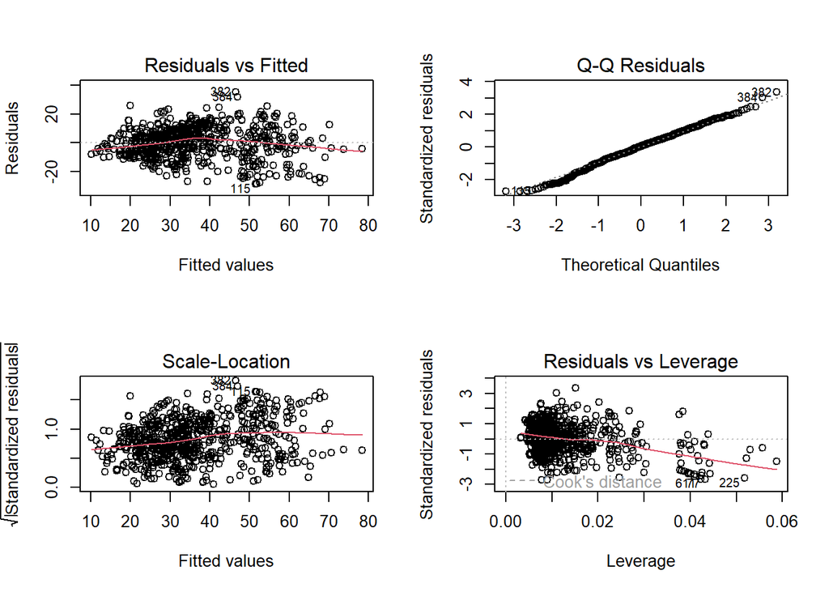

```r
# Graphical summary for the linear model
par(mfrow = c(2, 2))  # Arrange plots in a 2x2 grid
plot(lm_concrete)
```

```r
library(mgcv)
# Fit a Generalized Additive Model (GAM)
gam_concrete <- gam(Strength ~ s(Cement) + s(Slag) + s(FlyAsh) +
                      s(Water) + s(Superplast) + s(CoarseAggr) +
                      s(FineAggr) + s(Age),
                    data = train_set)

# Numerical summary of the fitted model
(summ_gam_concrete <- summary(gam_concrete))
```

```
##
## Family: gaussian
## Link function: identity
##
## Formula:
## Strength ~ s(Cement) + s(Slag) + s(FlyAsh) + s(Water) + s(Superplast) +
##     s(CoarseAggr) + s(FineAggr) + s(Age)
##
## Parametric coefficients:
##             Estimate Std. Error t value Pr(>|t|)
## (Intercept)  36.2460     0.2024   179.1   <2e-16 ***
## ---
## Signif. codes:  0 '***' 0.001 '**' 0.01 '*' 0.05 '.' 0.1 ' ' 1
##
## Approximate significance of smooth terms:
##                 edf Ref.df       F  p-value
## s(Cement)     8.339  8.866  33.865  < 2e-16 ***
## s(Slag)       5.415  6.495  19.543  < 2e-16 ***
## s(FlyAsh)     8.099  8.740   5.409 9.21e-07 ***
## s(Water)      8.731  8.970  20.880  < 2e-16 ***
## s(Superplast) 7.748  8.583   6.666  < 2e-16 ***
## s(CoarseAggr) 7.664  8.526   2.589  0.00702 **
## s(FineAggr)   8.538  8.927  12.052  < 2e-16 ***
## s(Age)        8.433  8.863 250.842  < 2e-16 ***
## ---
## Signif. codes:  0 '***' 0.001 '**' 0.01 '*' 0.05 '.' 0.1 ' ' 1
##
## R-sq.(adj) =  0.898   Deviance explained = 90.7%
## GCV = 31.551  Scale est. = 28.668    n = 700
```

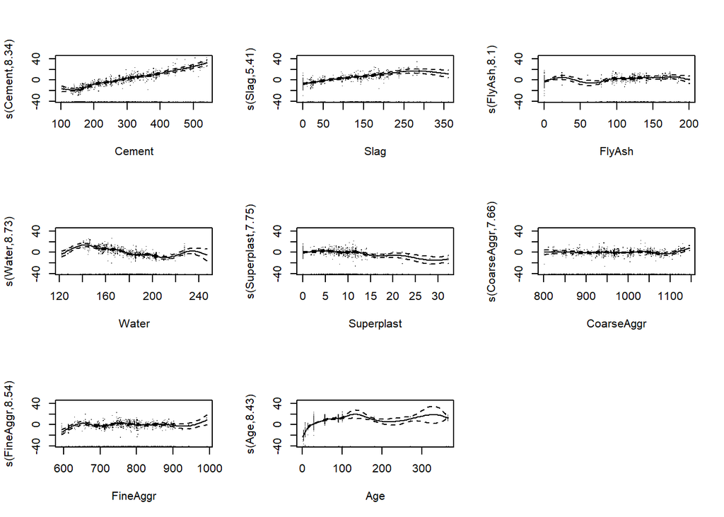

```r
# Graphical summary for the GAM model
par(mfrow = c(3, 3))
plot(gam_concrete, residuals = TRUE, rug = TRUE, pages = 1)
```

2. Compute the *Variable Importance* by Shapley values in the linear and gam fitted models. Compare your results with what you have learned before.

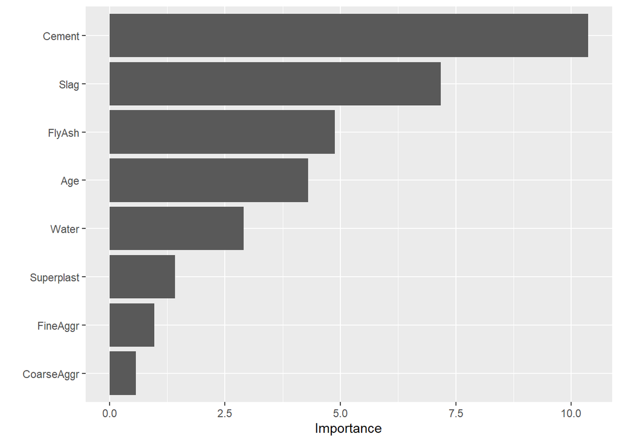

```r
# Compute Shapley values for the linear model
lm_concrete_shapley <- vip(
  lm_concrete,
  method = "shap",
  pred_wrapper = predict.lm,
  train = train_set,
  newdata = test_set,
  num_features = ncol(train_set) - 1,
  exact = TRUE
)

# Plot Shapley values for the linear model
plot(lm_concrete_shapley)
```

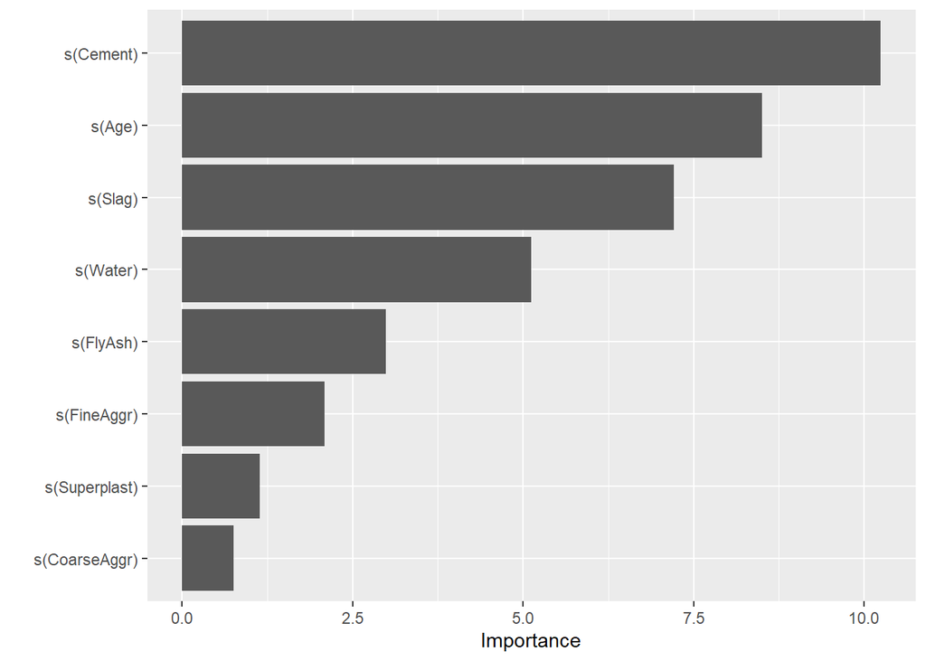

```r
# Compute Shapley values for the GAM
gam_concrete_shapley <- vip(
  gam_concrete,
  method = "shap",
  pred_wrapper = predict.gam,
  train = train_set,
  newdata = test_set,
  num_features = ncol(train_set) - 1,
  exact = TRUE
)

# Plot Shapley values for the GAM
plot(gam_concrete_shapley)
```

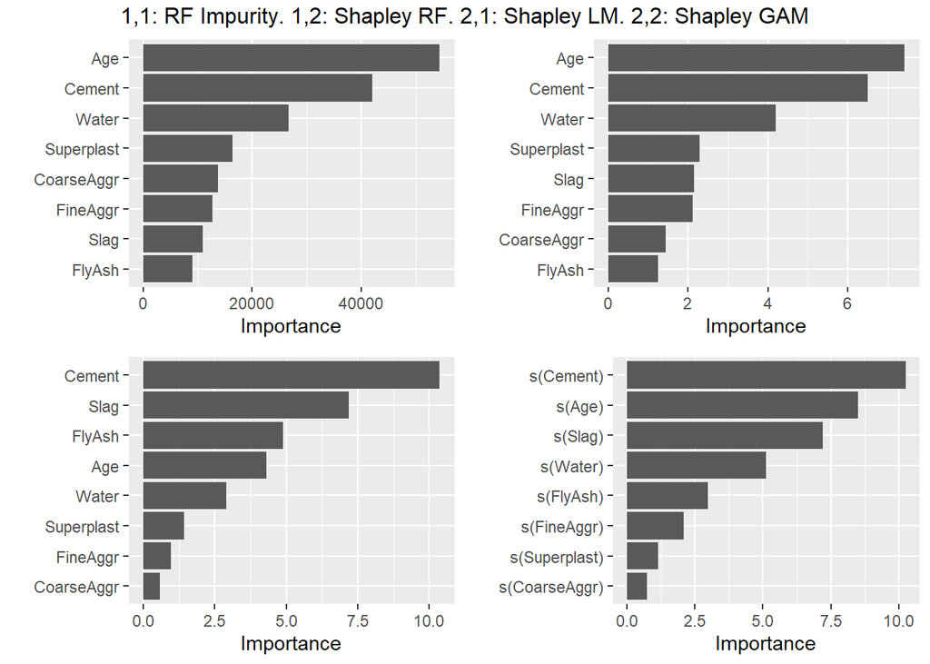

```r
# Combine all plots
grid.arrange(
  rf_imp_vip,
  rf_shapley,
  lm_concrete_shapley,
  gam_concrete_shapley,
  ncol = 2, nrow = 2,
  top = "1,1: RF Impurity. 1,2: Shapley RF. 2,1: Shapley LM. 2,2: Shapley GAM"
)
```

**3.Relevance by Ghost Variables**

Compute the relevance by ghost variables in the three fitted models.

```r
library(grid)
library(ggplot2)
source("relev.ghost.var.R")
```

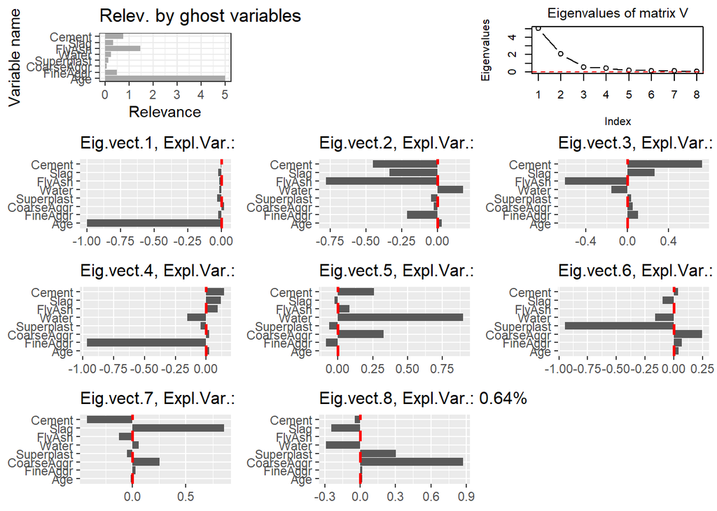

```r
# GAM model
Rel_Gh_Var_gam <- relev.ghost.var(
  model = gam_concrete,
  newdata = test_set[, -which(names(test_set) == "Strength")],
  y.ts = test_set$Strength,
  func.model.ghost.var = lm
)

par(mar = c(4, 4, 2, 1))
plot.relev.ghost.var(
  Rel_Gh_Var_gam,
  n1 = 500,
  ncols.plot = 3
)
```

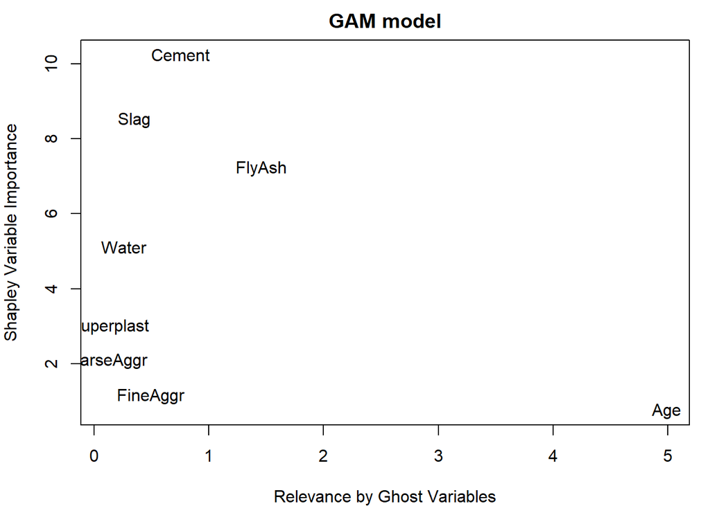

```r
# Combine ghost variable relevance with Shapley values
aux <- cbind(
  Rel_Gh_Var_gam$relev.ghost,
  gam_concrete_shapley$data$Importance
)

# Scatter plot
plot(aux[, 1], aux[, 2],
     col = 0,
     xlab = "Relevance by Ghost Variables",
     ylab = "Shapley Variable Importance",
     main = "GAM model")

# Add text labels for each variable
text(aux[, 1], aux[, 2], labels = row.names(aux))
```

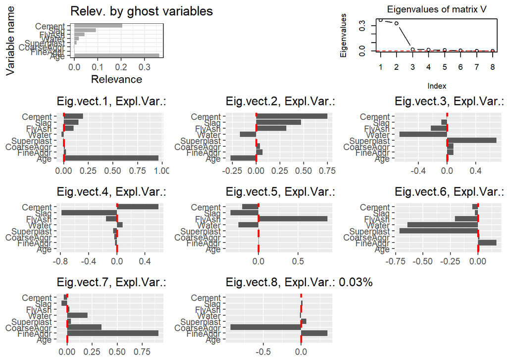

```r
Rel_Gh_Var_lm <- relev.ghost.var(
  model = lm_concrete,
  newdata = test_set[, -which(names(test_set) == "Strength")],
  y.ts = test_set$Strength,
  func.model.ghost.var = lm
)

par(mar = c(4, 4, 2, 1))
plot.relev.ghost.var(
  Rel_Gh_Var_lm,
  n1 = 500,
  ncols.plot = 3
)
```